# Stat 615 Final_Project

## 7.4 Let Reduce the above models by eliminating some variables

```r
lm(charges~  children+bmi+smoker+age:children+age:region+
     age:smoker+children:smoker+bmi:region+bmi:smoker+smoker+log(bmi)+
     bmi*bmi + log(age),insurance_new) -> interactionModelSignificant
summary(interactionModelSignificant)
```

```
##
## Call:
## lm(formula = charges ~ children + bmi + smoker + age:children +
##     age:region + age:smoker + children:smoker + bmi:region +
##     bmi:smoker + smoker + log(bmi) + bmi * bmi + log(age), data = insurance_new)
##
## Residuals:
##     Min      1Q  Median      3Q     Max
## -7189.3 -2334.9 -1166.7   385.6 21603.4
##
## Coefficients:
##                      Estimate Std. Error t value Pr(>|t|)
## (Intercept)          55898.45   31237.64   1.789  0.07461 .
## children              -319.02     745.49  -0.428  0.66902
## bmi                   1285.83     454.43   2.830  0.00499 **
## smokeryes           -17169.12    4145.36  -4.142 4.55e-05 ***
## log(bmi)            -30700.93   13026.61  -2.357  0.01911 *
## log(age)              5125.69    1406.95   3.643  0.00032 ***
## children:age            25.99      17.10   1.520  0.12966
## age:regionnorthwest    136.02      51.05   2.664  0.00815 **
## age:regionsoutheast    122.86      51.49   2.386  0.01769 *
## age:regionsouthwest    135.95      52.25   2.602  0.00976 **
## smokeryes:age          -71.61      50.30  -1.424  0.15563
## children:smokeryes   -1125.32     607.17  -1.853  0.06487 .
## bmi:regionnorthwest   -218.28      75.92  -2.875  0.00434 **
## bmi:regionsoutheast   -213.74      70.80  -3.019  0.00277 **
## bmi:regionsouthwest   -246.50      74.75  -3.297  0.00110 **
## bmi:smokeryes         1468.40     125.32  11.717  < 2e-16 ***
## ---
## Signif. codes:  0 '***' 0.001 '**' 0.01 '*' 0.05 '.' 0.1 ' ' 1
##
## Residual standard error: 4858 on 284 degrees of freedom
## Multiple R-squared:  0.8275, Adjusted R-squared:  0.8184
## F-statistic: 90.81 on 15 and 284 DF,  p-value: < 2.2e-16
```

```r
lm(charges~  children + bmi +
     smoker + age:children + age:region + age:smoker+
     + children:smoker + bmi:region +  bmi:smoker + smoker
   +  log(bmi)+ bmi*bmi + log(age)  , insurance_new) -> interactionModelSignificant

summary(interactionModelSignificant)
```

```
##
## Call:
## lm(formula = charges ~ children + bmi + smoker + age:children +
##     age:region + age:smoker + +children:smoker + bmi:region +
##     bmi:smoker + smoker + log(bmi) + bmi * bmi + log(age), data = insurance_new)
##
## Residuals:
##     Min      1Q  Median      3Q     Max
## -7189.3 -2334.9 -1166.7   385.6 21603.4
##
## Coefficients:
##                      Estimate Std. Error t value Pr(>|t|)
## (Intercept)          55898.45   31237.64   1.789  0.07461 .
## children              -319.02     745.49  -0.428  0.66902
## bmi                   1285.83     454.43   2.830  0.00499 **
## smokeryes           -17169.12    4145.36  -4.142 4.55e-05 ***
## log(bmi)            -30700.93   13026.61  -2.357  0.01911 *
## log(age)              5125.69    1406.95   3.643  0.00032 ***
## children:age            25.99      17.10   1.520  0.12966
## age:regionnorthwest    136.02      51.05   2.664  0.00815 **
## age:regionsoutheast    122.86      51.49   2.386  0.01769 *
## age:regionsouthwest    135.95      52.25   2.602  0.00976 **
## smokeryes:age          -71.61      50.30  -1.424  0.15563
## children:smokeryes   -1125.32     607.17  -1.853  0.06487 .
## bmi:regionnorthwest   -218.28      75.92  -2.875  0.00434 **
## bmi:regionsoutheast   -213.74      70.80  -3.019  0.00277 **
## bmi:regionsouthwest   -246.50      74.75  -3.297  0.00110 **
## bmi:smokeryes         1468.40     125.32  11.717  < 2e-16 ***
## ---
## Signif. codes:  0 '***' 0.001 '**' 0.01 '*' 0.05 '.' 0.1 ' ' 1
##
## Residual standard error: 4858 on 284 degrees of freedom
## Multiple R-squared:  0.8275, Adjusted R-squared:  0.8184
## F-statistic: 90.81 on 15 and 284 DF,  p-value: < 2.2e-16
```

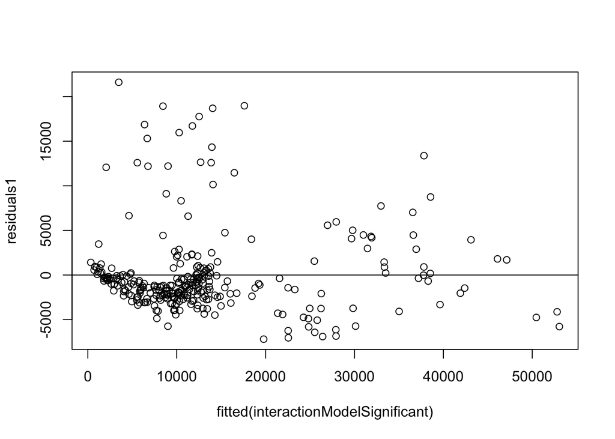

```
## integer(0)
```

```r
# The residual plot is not perfect but there is no clear pattern. So it should be relatively fine. It indicates relatively good amount of constant variance.

# Observing the residual vs fitted plot one can say that more points are plotted in one area specifically and no pattern can be found. So its normallly distributed.

resid(interactionModelSignificant) -> residuals1

plot(fitted(interactionModelSignificant), residuals1)+
abline(0,0)
```

## 7.5 CI for two of our chosen quantitative variables

- Using this regression model Let us take at least two variables and find confidence interval for the independent variables. Let us take two such as log(age) and bmi for example.
- The standard error for log(age) is 1406.95 and the coefficient is 5125.69 and standard error for bmi is 454 and the coefficient is 1285.83 .
- Degree of freedom is 284. (300-16). t is 1.9683. Which is closer to the z score actually.

```r
qt(p=.025, df=284, lower.tail = FALSE) -> t
t
```

```
## [1] 1.968352
```

```r
# so for bmi
#upper bound    2179.438
1285.83 + 1.9683 * 454
```

```
## [1] 2179.438
```

```r
# lower bound   392.2218
1285.83 - 1.9683 * 454
```

```
## [1] 392.2218
```

```r
# for log(age)
# upper bound ] 7894.99
5125.69 + 1.9683 * 1406.95
```

```
## [1] 7894.99
```

```r
# lower bound
5125.69 - 1.9683 * 1406.95
```

```
## [1] 2356.39
```